# Building My Analysis Dataset

Gender Gaps in Internet Access and Economic Outcomes

Shukria Alavi

September 25, 2026

# My research question

Does a smaller gender gap in internet access go together with better economic outcomes for women in developing countries?

I look at three outcomes: GDP per capita, female labour force participation, and female secondary school enrollment.

**What I want to know at this stage:**

1. How big is the internet gender gap, and how much does it vary between countries?
2. Do I have enough complete data to compare it against my three outcomes?

# Step 1: Load the three datasets

```r
internet  <- read_csv("data_raw/source1_internet_gender_findex.csv",
                      show_col_types = FALSE)
outcomes  <- read_csv("data_raw/source2_outcomes_worldbank.csv",
                      show_col_types = FALSE)
inequality <- read_csv("data_raw/source3_gii_undp.csv",
                       show_col_types = FALSE)
```

## Dataset 1: Internet use by gender

**Source:** World Bank Global Findex 2025. Gallup surveyed adults aged 15 and over in each country between May and December 2024 and asked whether they use the internet. Every country was surveyed in the same year with the same question, which is why I use this as my main measure.

The published file is 8,577 rows by 438 columns covering six survey years and every breakdown. `00_download_sources.R` narrows it to 2024, the gender breakdown, and the internet question, and converts the values from proportions to percentages.

This gives me my independent variable.

```r
dim(internet)
```

```
## [1] 90  5
```

```r
names(internet)
```

```
## [1] "country_code"   "country_name"   "survey_year"    "internet_women"
## [5] "internet_men"
```

```r
head(internet, 3)
```

```
## # A tibble: 3 × 5
##   country_code country_name survey_year internet_women internet_men
##   <chr>        <chr>              <dbl>          <dbl>        <dbl>
## 1 ALB          Albania             2024           86.7         78.6
## 2 DZA          Algeria             2024           83.5         82.4
## 3 ARG          Argentina           2024           90.1         85.9
```

## Dataset 2: Economic and education outcomes

**Source:** World Bank World Development Indicators. This gives me my three outcome variables plus two control variables. For each country I took the most recent value between 2021 and 2024, and kept a column recording which year it came from.

```r
dim(outcomes)
```

```
## [1] 131  12
```

```r
names(outcomes)
```

```
##  [1] "country_code"              "country_name"
##  [3] "flfp"                      "gdp_pc_ppp"
##  [5] "internet_total"            "sec_enroll_fem_gross"
##  [7] "urban_pct"                 "flfp_year"
##  [9] "gdp_pc_ppp_year"           "internet_total_year"
## [11] "sec_enroll_fem_gross_year" "urban_pct_year"
```

```r
head(outcomes, 3)
```

```
## # A tibble: 3 × 12
##   country_code country_name  flfp gdp_pc_ppp internet_total sec_enroll_fem_gross
##   <chr>        <chr>        <dbl>      <dbl>          <dbl>                <dbl>
## 1 AFG          Afghanistan   5.12      1964.           16.1                 45.2
## 2 ALB          Albania      58.2      21641.           85.9                107.
## 3 DZA          Algeria      14.3      15502.           77.4                107.
## # ℹ 6 more variables: urban_pct <dbl>, flfp_year <dbl>, gdp_pc_ppp_year <dbl>,
## #   internet_total_year <dbl>, sec_enroll_fem_gross_year <dbl>,
## #   urban_pct_year <dbl>
```

## Dataset 3: Gender Inequality Index

**Source:** UNDP Human Development Report 2025. The Gender Inequality Index combines maternal mortality, adolescent births, seats in parliament, education and labour force participation into one score from 0 to 1, where higher means more unequal. I use it as a control.

```r
dim(inequality)
```

```
## [1] 116   4
```

```r
names(inequality)
```

```
## [1] "country_code"            "country_name"
## [3] "gender_inequality_index" "gii_year"
```

```r
head(inequality, 3)
```

```
## # A tibble: 3 × 4
##   country_code country_name gender_inequality_index gii_year
##   <chr>        <chr>                          <dbl>    <dbl>
## 1 AFG          Afghanistan                    0.661     2023
## 2 ALB          Albania                        0.107     2023
## 3 DZA          Algeria                        0.443     2023
```

# Step 2: Checking the datasets before joining

If the column I join on does not match across files, countries disappear without any error message. So I check first.

*Does any country appear twice?*

```r
sum(duplicated(internet$country_code))
```

```
## [1] 0
```

```r
sum(duplicated(outcomes$country_code))
```

```
## [1] 0
```

```r
sum(duplicated(inequality$country_code))
```

```
## [1] 0
```

All zero, so each country appears once in each file.

**Which countries are in one file but not another?**

`anti_join` shows rows on the left with no match on the right.

```r
anti_join(internet, outcomes, by = "country_code") %>%
  select(country_code, country_name)
```

```
## # A tibble: 0 × 2
## # ℹ 2 variables: country_code <chr>, country_name <chr>
```

```r
anti_join(internet, inequality, by = "country_code") %>%
  select(country_code, country_name)
```

```
## # A tibble: 3 × 2
##   country_code country_name
##   <chr>        <chr>
## 1 XKX          Kosovo
## 2 UKR          Ukraine
## 3 PSE          West Bank and Gaza
```

Every country in my internet data is also in the World Bank file. Three are missing from the UNDP file, so they will have no Gender Inequality Index.

**Are country names spelled the same way?**

```r
name_check <- internet %>%
  select(country_code, name_worldbank = country_name) %>%
  inner_join(inequality %>% select(country_code, name_undp = country_name),
             by = "country_code")

name_check %>% filter(name_worldbank != name_undp)
```

```
## # A tibble: 14 × 3
##    country_code name_worldbank     name_undp
##    <chr>        <chr>              <chr>
##  1 BOL          Bolivia            Bolivia (Plurinational State of)
##  2 COD          Congo, Dem. Rep.   Congo (Democratic Republic of the)
##  3 COG          Congo, Rep.        Congo
##  4 CIV          Cote d'Ivoire      Côte d'Ivoire
##  5 EGY          Egypt, Arab Rep.   Egypt
##  6 SWZ          Eswatini           Eswatini (Kingdom of)
##  7 GMB          Gambia, The        Gambia
##  8 IRN          Iran, Islamic Rep. Iran (Islamic Republic of)
##  9 KGZ          Kyrgyz Republic    Kyrgyzstan
## 10 LAO          Lao PDR            Lao People's Democratic Republic
## 11 MDA          Moldova            Moldova (Republic of)
## 12 TZA          Tanzania           Tanzania (United Republic of)
## 13 TUR          Turkiye            Türkiye
## 14 VEN          Venezuela, RB      Venezuela (Bolivarian Republic of)
```

```r
name_check %>%
  summarise(total = n(),
            same_spelling      = sum(name_worldbank == name_undp),
            different_spelling = sum(name_worldbank != name_undp))
```

```
## # A tibble: 1 × 3
##   total same_spelling different_spelling
##   <int>         <int>              <int>
## 1    87            73                 14
```

**This is the most important check on the page.** 14 countries are spelled differently between the two organisations. The World Bank writes “Egypt, Arab Rep.” where the UNDP writes “Egypt”, and “Kyrgyz Republic” where the UNDP writes “Kyrgyzstan”.

If I had joined on country name, those 14 countries would have silently dropped out and I would never have known. This is why I join on the three-letter **country code**, which is standardised across organisations.

# Step 3: Joining

`left_join` keeps every row on the left and adds matching columns from the right. Where there is no match it fills in `NA` instead of dropping the row.

I start from the internet data, because a country with no gender gap measure is no use to me.

```r
data <- internet %>%
  left_join(outcomes,   by = "country_code") %>%
  left_join(inequality, by = "country_code")

dim(data)
```

```
## [1] 90 19
```

The join added **columns**, not rows.

```r
nrow(internet)                    # before
```

```
## [1] 90
```

```r
nrow(data)                        # after
```

```
## [1] 90
```

```r
sum(duplicated(data$country_code))  # should be 0
```

```
## [1] 0
```

The join brought in three copies of the country name, one per file. I keep one.

```r
data <- data %>%
  select(-country_name.y, -country_name) %>%
  rename(country = country_name.x)
```

# Step 4: Cleaning

Each decision below says what I did and why.

**Build the gender gap variable**

The gap is not in any dataset. I calculate it from the male and female columns.

```r
data <- data %>%
  mutate(
    gap_diff  = internet_men - internet_women,   # percentage points; + means men ahead
    gap_ratio = internet_women / internet_men    # 1.0 means equal
  )
```

**Droping Kosovo**

Kosovo is missing female labour force participation, overall internet use, and the Gender Inequality Index. That is most of what I need. R would exclude it from nearly every model anyway, so removing it on purpose keeps my stated sample size honest.

```r
data <- data %>% filter(country != "Kosovo")
nrow(data)
```

```
## [1] 89
```

**Add a logged GDP column**

GDP per capita is skewed, with a few countries much richer than the rest. Taking the log evens it out, which is standard before using it in a model.

```r
data <- data %>% mutate(log_gdp = log(gdp_pc_ppp))
```

**Keep the columns I actually use**

```r
data <- data %>%
  select(country_code, country,
         internet_women, internet_men, gap_diff, gap_ratio,
         gdp_pc_ppp, log_gdp, flfp, sec_enroll_fem_gross,
         internet_total, urban_pct, gender_inequality_index)

dim(data)
```

```
## [1] 89 13
```

```r
names(data)
```

```
##  [1] "country_code"            "country"
##  [3] "internet_women"          "internet_men"
##  [5] "gap_diff"                "gap_ratio"
##  [7] "gdp_pc_ppp"              "log_gdp"
##  [9] "flfp"                    "sec_enroll_fem_gross"
## [11] "internet_total"          "urban_pct"
## [13] "gender_inequality_index"
```

**What I did NOT do**

- I did not remove outliers. Pakistan has the widest gap and the data is correct, so it stays.
- I did not fill in missing values. I report them instead.

# Step 5: Check the cleaned data

```r
nrow(data)
```

```
## [1] 89
```

```r
sum(duplicated(data$country_code))
```

```
## [1] 0
```

```r
data %>%
  summarise(across(c(gap_diff, gdp_pc_ppp, flfp, sec_enroll_fem_gross,
                     internet_total, urban_pct, gender_inequality_index),
                   ~ sum(is.na(.)))) %>%
  pivot_longer(everything(), names_to = "variable", values_to = "missing") %>%
  arrange(desc(missing))
```

```
## # A tibble: 7 × 2
##   variable                missing
##   <chr>                     <int>
## 1 sec_enroll_fem_gross         15
## 2 gender_inequality_index       2
## 3 gdp_pc_ppp                    1
## 4 gap_diff                      0
## 5 flfp                          0
## 6 internet_total                0
## 7 urban_pct                     0
```

# Step 6: Look at each variable on its own

**The internet gender gap**

```r
summary(data$gap_diff)
```

```
##    Min. 1st Qu.  Median    Mean 3rd Qu.    Max.
##  -8.040   0.200   4.790   6.064  12.310  43.610
```

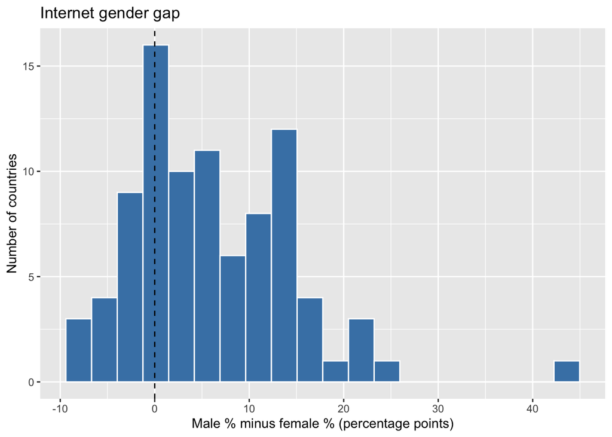

```r
ggplot(data, aes(x = gap_diff)) +
  geom_histogram(bins = 20, fill = "steelblue", colour = "white") +
  geom_vline(xintercept = 0, linetype = "dashed") +
  labs(title = "Internet gender gap",
       x = "Male % minus female % (percentage points)",
       y = "Number of countries")
```

```r
data %>% arrange(desc(gap_diff)) %>%
  select(country, internet_women, internet_men, gap_diff) %>% head(5)
```

```
## # A tibble: 5 × 4
##   country          internet_women internet_men gap_diff
##   <chr>                     <dbl>        <dbl>    <dbl>
## 1 Pakistan                   13.6         57.2     43.6
## 2 Burkina Faso               20.2         43.8     23.5
## 3 Kenya                      49.6         71.9     22.2
## 4 Egypt, Arab Rep.           44.0         65.6     21.6
## 5 Iraq                       65.5         86.2     20.7
```

```r
data %>% arrange(gap_diff) %>%
  select(country, internet_women, internet_men, gap_diff) %>% head(5)
```

```
## # A tibble: 5 × 4
##   country     internet_women internet_men gap_diff
##   <chr>                <dbl>        <dbl>    <dbl>
## 1 Albania               86.7         78.6    -8.04
## 2 Armenia               90.9         83.4    -7.49
## 3 Philippines           74.0         67.3    -6.76
## 4 Lao PDR               73.4         67.0    -6.39
## 5 China                 89.2         83.4    -5.75
```

**GDP per capita**

```r
summary(data$gdp_pc_ppp)
```

```
##    Min. 1st Qu.  Median    Mean 3rd Qu.    Max.    NA's
##    1501    4686   10427   12043   17003   36154       1
```

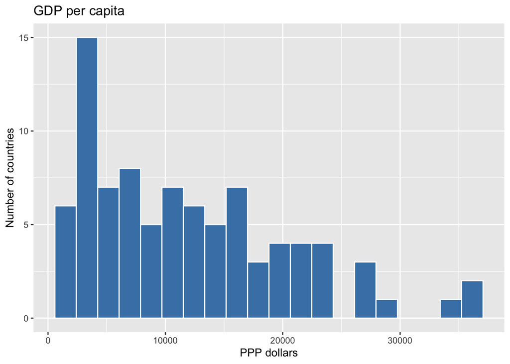

```r
ggplot(data, aes(x = gdp_pc_ppp)) +
  geom_histogram(bins = 20, fill = "steelblue", colour = "white") +
  labs(title = "GDP per capita", x = "PPP dollars", y = "Number of countries")
```

**Female labour force participation**

```r
summary(data$flfp)
```

```
##    Min. 1st Qu.  Median    Mean 3rd Qu.    Max.
##   11.00   39.62   51.72   49.82   59.47   82.92
```

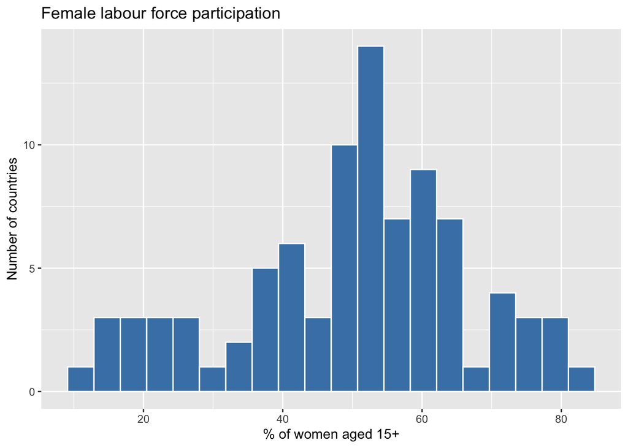

```r
ggplot(data, aes(x = flfp)) +
  geom_histogram(bins = 20, fill = "steelblue", colour = "white") +
  labs(title = "Female labour force participation",
       x = "% of women aged 15+", y = "Number of countries")
```

**Female secondary enrollment**

```r
summary(data$sec_enroll_fem_gross)
```

```
##    Min. 1st Qu.  Median    Mean 3rd Qu.    Max.    NA's
##   19.44   59.60   86.38   78.32   94.15  116.87      15
```

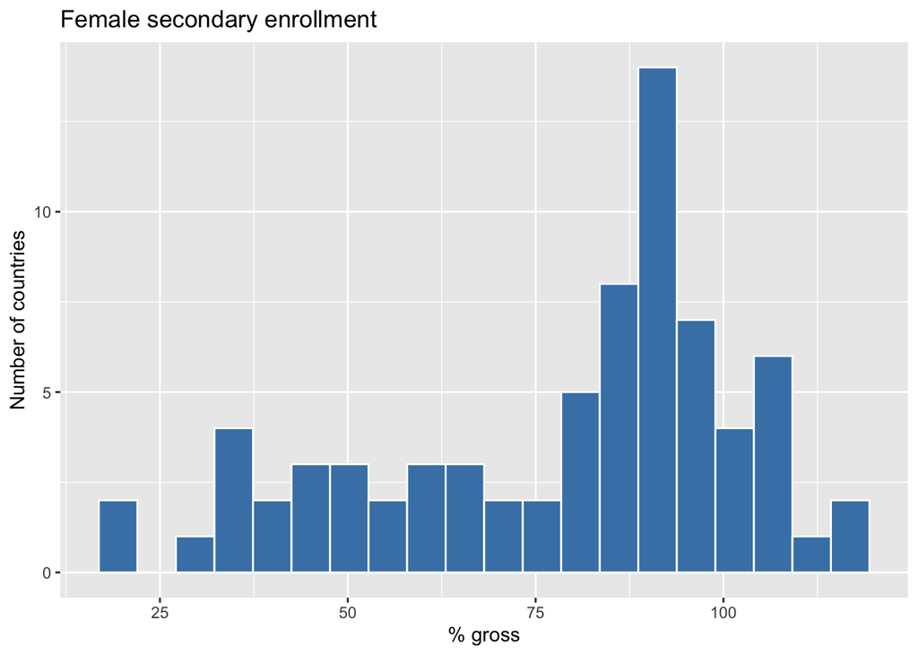

```r
ggplot(data, aes(x = sec_enroll_fem_gross)) +
  geom_histogram(bins = 20, fill = "steelblue", colour = "white") +
  labs(title = "Female secondary enrollment",
       x = "% gross", y = "Number of countries")
```

# Step 7: Save

```r
if (!dir.exists("data_clean")) dir.create("data_clean")
write_csv(data, "data_clean/analysis_data.csv")
```

**Where I am**

- I have **89 countries** with a gender gap measure and most outcomes.
- The gap ranges from women being ahead by 8 points to men being ahead by 44.
- 15 countries have no female secondary enrollment figure, which is my weakest outcome variable.